# Computational Text Analysis: Sampling text demo

Marion Lieutaud

3/12/2024

This exercise is part of the course Data for Data Scientists taught at LSE’s department of Methodology (current conveners: Tom Robinson and Dan De Kadt)

# Selecting elements

```r
library(tidyverse)
library(rvest)
```

Let us use our simple self-made website to illustrate how elements of websites can be selected and scraped. First, let us read the HTML content of the site:

```r
url <- "https://lse-my472.github.io/week05/data/website_5.html"
html <- read_html(url)
```

Next, let us scrape all paragraphs from our website. Recall that the CSS selector of a paragraph was “p”.

```r
relevant_elements <- html_elements(html, css = "p")
length(relevant_elements)
```

```
## [1] 5
```

The list has length 5, i.e. we obtain 5 nodes as there are 5 paragraphs in our website. In more detail:

```r
relevant_elements
```

```
## {xml_nodeset (5)}
## [1] <p>A first paragraph.</p>
## [2] <p>A second paragraph with some <b>formatted</b> text.</p>
## [3] <p class="text-about-web-scraping">A third paragraph now containing some  ...
## [4] <p>Another paragraph with some text.</p>
## [5] <p class="text-about-web-scraping">A last paragraph discussing some web s ...
```

If we want to return the text without HMTL tags, we can use the function “html_text()”. For example, the first element has the following text:

```r
html_text(relevant_elements[[1]])
```

```
## [1] "A first paragraph."
```

We can return the texts of all paragraphs contained in the list with a loop:

```r
for (i in 1:length(relevant_elements)) {

  print(html_text(relevant_elements[[i]]))

}
```

```
## [1] "A first paragraph."
## [1] "A second paragraph with some formatted text."
## [1] "A third paragraph now containing some text about web scraping ..."
## [1] "Another paragraph with some text."
## [1] "A last paragraph discussing some web scraping ..."
```

Now imagine we do not want to scrape all paragraph texts. Fortunately, paragraphs (or more likely other elements) about certain topics could have been assigned different class names by the developers who built the website. In our example, we made up a class for paragraphs that could discuss topics in web scraping, the associated class was “text-about-web-scraping”. In CSS selector notation this is “.text-about-web-scraping”. We can scrape only these paragraphs with:

```r
relevant_elements <- html_elements(html, css = ".text-about-web-scraping")
relevant_elements
```

```
## {xml_nodeset (2)}
## [1] <p class="text-about-web-scraping">A third paragraph now containing some  ...
## [2] <p class="text-about-web-scraping">A last paragraph discussing some web s ...
```

```r
# Printing all elements
for (i in 1:length(relevant_elements)) {

  print(html_text(relevant_elements[[i]]))

}
```

```
## [1] "A third paragraph now containing some text about web scraping ..."
## [1] "A last paragraph discussing some web scraping ..."
```

Similarly, we can scrape the content from only the second division container. We had given it a class name of “division-two”, so in CSS selector notation it is called “.division-two”:

```r
relevant_elements <- html_elements(html, css = ".division-two")
length(relevant_elements)
```

```
## [1] 1
```

In fact, only one node is returned in the list. It is the correct division container with text:

```r
html_text(relevant_elements[[1]])
```

```
## [1] "\n            Heading of the second division\n            Another paragraph with some text.\n            A last paragraph discussing some web scraping ...\n        "
```

Lastly, when inspecting an element and copying the CSS selector in your browser, often a so called pseudo class is returned which names the nth child of a parent element. Conceptually, this makes use of the tree representation of such documents. For example, let us select and scrape only the first paragraph in the second division. “Inspect element” (in Firefox) yields exactly such a type of CSS selector “.division-two > p:nth-child(2)”. This simply means that the paragraph of interest is the second child of the division parent element “div” which we previously named “division two”. Thinking of our website as a tree, what is the first child of this parent element?

*Replace ’tba’in code chunk underneath with the appropriate selector* Scraping with this CSS selector yields the correct element from our website:

```r
relevant_elements <- html_elements(html, css = 'tba')
html_text(relevant_elements[[1]])
```

# Scraping tables

### Scraping web data in table format

The goal of this exercise is to scrape the counts of social security number applicants by year in the US, and then clean the data so that we can generate a plot showing the evolution in this variable over time.

The first step is to read the html code from the website we want to scrape using the `read_html()` function. If we want to see the html in text format, we can then use `html_text()`.

```r
url <- "https://www.ssa.gov/oact/babynames/numberUSbirths.html"
# Storing the url's HTML code
html_content <- read_html(url)
```

```r
# Not very informative
str(html_content)
```

```
## List of 2
##  $ node:<externalptr>
##  $ doc :<externalptr>
##  - attr(*, "class")= chr [1:2] "xml_document" "xml_node"
```

```r
print(html_content)
```

```
## {html_document}
## <html class="no-js" lang="en">
## [1] <head>\n<meta http-equiv="Content-Type" content="text/html; charset=UTF-8 ...
## [2] <body>\r\n  <!-- BANNER -->\r\n  <aside class="accessibility" id="accessi ...
```

```r
# Looking at first 1000 characters
substr(html_content, 1, 1000)
```

```
## [1] "<!DOCTYPE html>\n<html class=\"no-js\" lang=\"en\">\n<head>\n<meta http-equiv=\"Content-Type\" content=\"text/html; charset=UTF-8\">\n<!-- REQUIRED META INFORMATION --><meta charset=\"UTF-8\">\n<meta http-equiv=\"X-UA-Compatible\" content=\"IE=edge\">\n<meta name=\"viewport\" content=\"width…
```

To extract all the tables in the html code automatically, we use `html_table()`. Note that it returns a list of data frames which has length 1 here as there is only one table on this website.

```r
# Extracting tables in the document
tab <- html_table(html_content, fill = TRUE)

# Check object
str(tab)
```

```
## List of 1
##  $ : tibble [143 × 4] (S3: tbl_df/tbl/data.frame)
##   ..$ Year of birth: int [1:143] 1880 1881 1882 1883 1884 1885 1886 1887 1888 1889 ...
##   ..$ Male         : chr [1:143] "118,399" "108,279" "122,031" "112,475" ...
##   ..$ Female       : chr [1:143] "97,606" "98,855" "115,694" "120,060" ...
##   ..$ Total        : chr [1:143] "216,005" "207,134" "237,725" "232,535" ...
```

```r
# Website only had one table -> list of length 1 containing the dataframe

# Save the dataframe (tibble)
social_security_data <- tab[[1]]
social_security_data <- as_tibble(social_security_data)
social_security_data
```

```
## # A tibble: 143 × 4
##    `Year of birth` Male    Female  Total
##              <int> <chr>   <chr>   <chr>
##  1            1880 118,399 97,606  216,005
##  2            1881 108,279 98,855  207,134
##  3            1882 122,031 115,694 237,725
##  4            1883 112,475 120,060 232,535
##  5            1884 122,738 137,585 260,323
##  6            1885 115,945 141,947 257,892
##  7            1886 119,041 153,734 272,775
##  8            1887 109,311 155,423 264,734
##  9            1888 129,906 189,445 319,351
## 10            1889 119,032 189,218 308,250
## # ℹ 133 more rows
```

Now let us clean the data so that we can use it for our analysis. We need to convert the population values into a numeric format, which requires deleting the commas. We will also change the variable names so that it is easier to work with them.

```r
## Remove commas and then make variable numeric
social_security_data$Male <-  as.numeric(gsub(",", "", social_security_data$Male))
social_security_data$Female <- as.numeric(gsub(",", "", social_security_data$Female))
social_security_data$Total <- as.numeric(gsub(",", "", social_security_data$Total))

## Rename variables
colnames(social_security_data) <- c('year', 'male', 'female', 'total')
```

Now we can plot to see how the number of people applying for a Social Security Number in the US has increased over time (using `ggplot2` requires the data to be in a tidy long format):

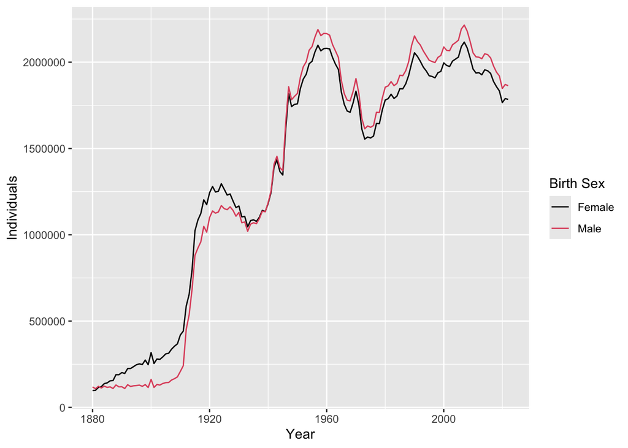

```r
# Pivot longer function
social_security_data_long <- pivot_longer(data = social_security_data[, 1:3],
  cols = c("male", "female"), names_to = "sex", values_to = "individuals")

# Creating the plot
ggplot(social_security_data_long) +
  aes(x = year, y = individuals, group = sex, colour = sex) +
  geom_line() + xlab("Year") + ylab("Individuals") +
  scale_colour_manual(name ="Birth Sex", values = c(1, 2), labels = c("Female", "Male"))
```

### Scraping web data in table format: A more advanced example

When there are multiple tables on the website, scraping them becomes a bit more complicated. Let’s work through an exemplary scenario: Scraping a table from Wikipedia with a list of the most populated cities in the United States.

```r
url <- "https://en.wikipedia.org/wiki/List_of_United_States_cities_by_population"
html <- read_html(url)
tables <- html_table(html, fill=TRUE)
class(tables)
```

```
## [1] "list"
```

```r
length(tables)
```

```
## [1] 10
```

The function returns 10 different tables (checked 12/03/2024). The option `fill=TRUE` is used because some of the tables appear to have incomplete rows.

One option is to go through these tables in this list manually and select the correct one:

```r
tables[3] # position 3 happens to be the correct table (checked 12/03/2024)
```

```
## [[1]]
## # A tibble: 334 × 10
##    City            ST    `2022estimate` `2020census` Change `2020 land area`
##    <chr>           <chr> <chr>          <chr>        <chr>  <chr>
##  1 City            ST    2022estimate   2020census   Change mi2
##  2 New York[c]     NY    8,335,897      8,804,190    −5.32% 300.5
##  3 Los Angeles     CA    3,822,238      3,898,747    −1.96% 469.5
##  4 Chicago         IL    2,665,039      2,746,388    −2.96% 227.7
##  5 Houston         TX    2,302,878      2,304,580    −0.07% 640.4
##  6 Phoenix         AZ    1,644,409      1,608,139    +2.26% 518.0
##  7 Philadelphia[d] PA    1,567,258      1,603,797    −2.28% 134.4
##  8 San Antonio     TX    1,472,909      1,434,625    +2.67% 498.8
##  9 San Diego       CA    1,381,162      1,386,932    −0.42% 325.9
## 10 Dallas          TX    1,299,544      1,304,379    −0.37% 339.6
## # ℹ 324 more rows
## # ℹ 4 more variables: `2020 land area` <chr>, `2020 density` <chr>,
## #   `2020 density` <chr>, Location <chr>
```

Alternatively, the table of interest can be identified directly with a right-click and “Inspect” or “Inspect Element” in the browser. Clicking on the relevant part of the page’s code, then right-click ‘copy’ and select (in this case) ‘CSS selector’.

CSS selector: table.sortable:nth-child(30) (extracted with Firefox “Inspect Element” on 12/03/2024)

An alternative option is to look at the full source code of the website. In Google Chrome e.g., go to *View* > *Developer* > *View Source*. All browsers should have similar options to view the source code of a website. In the source code, search for the text of the page (e.g. *2022 rank*). Right above it you will see: `<table class="wikitable sortable ..." ...>`. This is the CSS selector. Using this selector, however, might still return several tables.

Now that we know what we’re looking for, let’s use `html_elements()` to identify all the elements of the page that have that CSS class (note that we use a dot before the name of the class because the R function expects CSS notation). Whereas we will find several elements with the CSS selector “.wikitable” which we would have to search subsequently, we will only find one with the very specific selector obtained with inspect element.

*Replace ’tba’in code chunk underneath with the appropriate selector*

```r
table_raw <- html_elements(html, css = 'table.sortable:nth-child(30)')
length(table_raw) # now a list of length 1
```

```
## [1] 1
```

Transforming into a tibble with `html_table()`:

```r
data_pop <- html_table(table_raw[[1]], fill = TRUE)
data_pop
```

```
## # A tibble: 334 × 10
##    City            ST    `2022estimate` `2020census` Change `2020 land area`
##    <chr>           <chr> <chr>          <chr>        <chr>  <chr>
##  1 City            ST    2022estimate   2020census   Change mi2
##  2 New York[c]     NY    8,335,897      8,804,190    −5.32% 300.5
##  3 Los Angeles     CA    3,822,238      3,898,747    −1.96% 469.5
##  4 Chicago         IL    2,665,039      2,746,388    −2.96% 227.7
##  5 Houston         TX    2,302,878      2,304,580    −0.07% 640.4
##  6 Phoenix         AZ    1,644,409      1,608,139    +2.26% 518.0
##  7 Philadelphia[d] PA    1,567,258      1,603,797    −2.28% 134.4
##  8 San Antonio     TX    1,472,909      1,434,625    +2.67% 498.8
##  9 San Diego       CA    1,381,162      1,386,932    −0.42% 325.9
## 10 Dallas          TX    1,299,544      1,304,379    −0.37% 339.6
## # ℹ 324 more rows
## # ℹ 4 more variables: `2020 land area` <chr>, `2020 density` <chr>,
## #   `2020 density` <chr>, Location <chr>
```

As in the previous case, we still need to clean the data before we can use it. For this particular example, let’s see if this dataset provides evidence in support of [Zipf’s law for population ranks](https://en.wikipedia.org/wiki/Zipf%27s_law). Keeping only the columns of interest and transforming into a tibble:

```r
data_pop <- data_pop %>%
  select("City", "2022estimate") %>%
  filter(row_number() != 1) %>% # removing first row as it repeats the header
  mutate(`2022rank` = row_number()) # using the row number as rank since the table is ranked
```

Renaming and cleaning columns:

```r
# Renaming the columns
data_pop <- rename(data_pop, city_name = "City",
                   rank = "2022rank",
                   population = "2022estimate")

# Removing superscripts in the city names
data_pop$city_name <- gsub("\\[.*\\]", "", data_pop$city_name)

# Removes commas and transform population figures into numbers
data_pop$population <- as.numeric(gsub(",", "", data_pop$population))

data_pop
```

```
## # A tibble: 333 × 3
##    city_name    population  rank
##    <chr>             <dbl> <int>
##  1 New York        8335897     1
##  2 Los Angeles     3822238     2
##  3 Chicago         2665039     3
##  4 Houston         2302878     4
##  5 Phoenix         1644409     5
##  6 Philadelphia    1567258     6
##  7 San Antonio     1472909     7
##  8 San Diego       1381162     8
##  9 Dallas          1299544     9
## 10 Austin           974447    10
## # ℹ 323 more rows
```

Now we’re ready to generate the figure:

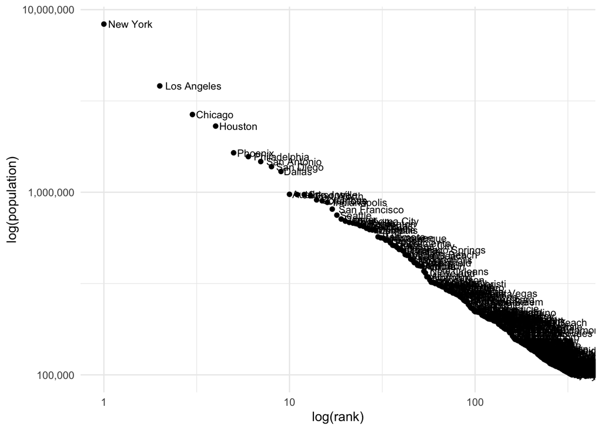

```r
p <- ggplot(data_pop, aes(x=rank, y=population, label=city_name)) +
  geom_point() + geom_text(hjust=-.1, size=3) +
    scale_x_log10("log(rank)") +
  scale_y_log10("log(population)", labels=scales::comma) +
  theme_minimal()
p
```

These power laws (https://en.wikipedia.org/wiki/Power_law) are remarkably general. For example, have a look how the first 10 million words in 30 Wikipedias (dumps from October 2015): https://en.wikipedia.org/wiki/Zipf%27s_law#/media/File:Zipf_30wiki_en_labels.png

Side note: We can also try to get an idea whether the distribution follows Zipf’s law by estimating a log-log linear regression.

```r
summary(lm(log(rank) ~ log(population), data = data_pop))
```

```
##
## Call:
## lm(formula = log(rank) ~ log(population), data = data_pop)
##
## Residuals:
##      Min       1Q   Median       3Q      Max
## -0.30301 -0.02213 -0.00801  0.02339  0.37588
##
## Coefficients:
##                  Estimate Std. Error t value Pr(>|t|)
## (Intercept)     21.759686   0.048358   450.0   <2e-16 ***
## log(population) -1.389022   0.003959  -350.9   <2e-16 ***
## ---
## Signif. codes:  0 '***' 0.001 '**' 0.01 '*' 0.05 '.' 0.1 ' ' 1
##
## Residual standard error: 0.0502 on 331 degrees of freedom
## Multiple R-squared:  0.9973, Adjusted R-squared:  0.9973
## F-statistic: 1.231e+05 on 1 and 331 DF,  p-value: < 2.2e-16
```

# Dynamic scraping

### RSelenium

Note: Using `RSelenium` usually requires Java DK. First, try to see whether it is already installed on your computer - only install `RSelenium` with `install.packages("RSelenium")` and try to run the code in this document. If that does not work properly, next try to install Java DK. You can download the current version from here: https://www.oracle.com/java/technologies/downloads/. After its installation, restart RStudio.

Loading the Selenium package:

```r
#install.packages("RSelenium") -- run once to install the package on your computer
library("RSelenium")
#install.packages("netstat") -- this is optional, to allow the use of free_port()
library("netstat")
```

Launching the driver and browser (if the port is already in use, choose a different number with four digits, e.g. `rsDriver(browser=c("firefox"), port = 1234L)`). Alternatively – as we do here – choose a random free port using `netstat:free_port`. This code will now open what we call a ‘marionette’ browser (you can figure out why). Do not close this browser window!

```r
# note that we use 'chromever = NULL' as chrome drivers seem to be buggy as of 11/6/23
rD <- rsDriver(browser=c("firefox"), port = free_port(random = TRUE), chromever = NULL)
```

[output not shown]

[output cut: 19 more lines]

[output not shown]

```r
driver <- rD$client
```

Key Selenium functions: click, find content, enter content, press ‘ENTER’

```r
some_element$clickElement()
```

Find element (e.g. a search box)

```r
search_box <- driver$findElement(using = "xpath", value = '...')
```

Enter some text

```r
search_box$sendKeysToElement(list("some text"))
```

Press enter key

```r
search_box$sendKeysToElement(list(key = "enter"))
```

### Selenium example with Edinburgh Uni

Create browser instance with·

```r
# don't run this if you've already opened a marionnette browser
rD <- rsDriver(browser=c("firefox"), chromever = NULL)
driver <- rD$client
```

Navigate to url

```r
driver$navigate("https://www.ed.ac.uk/finance/transparency/foi/investments")
```

We need to deal with pop up on cookies. First we need to select our cookies settings

```r
cookies_tick1 <- driver$findElement(using = "css", value = "#edgel-cookie-setting-2")

cookies_tick1$clickElement()

Sys.sleep(1) # give it some time

cookies_tick2 <- driver$findElement(using = "css", value = "#edgel-cookie-setting-4")

cookies_tick2$clickElement()
```

Then we need to press ‘save settings’ at the end.

```r
cookiessavebox <- driver$findElement(using = "css", value = ".cookie-btn")

cookiessavebox$clickElement()
# done
```

Compare Xpaths

```r
#"/html/body/div[6]/div/div[2]/div[2]/section/div[2]/div/div/a"
#"/html/body/div[6]/div/div[2]/div[2]/section/div[9]/div/div/a"

investments_list <- "/html/body/div[6]/div/div[2]/div[2]/section/div[*]/div/div/a"
```

### Exercise: Google search

Navigate to the Google website

```r
url <- "https://www.google.com/"
driver$navigate(url)
```

Since recently there can be new privacy terms that have to be accepted once in some regions.

Side note: Some such cases with pop-up windows on websites might require frame switching (although it seems that the 2023 version of Google does not require this at the moment). Should the code below not run on your computer after you have entered the correct XPath, try to uncomment the `swithToFrame` functions. As the the window is in the foreground, it can be that we have to switch the frame. Without this switching of the frame, we might not be able to click on the right element. Whether switching the frame is necessary depends on the design of the underlying website which can change.

As an exercise, the XPaths of the relevant elements have to be obtained with the Inspect function of the browser and then be pasted into this code replacing the ‘tba’.

```r
#driver$switchToFrame(0) # can be un-commented and tried if code does not run

# note the use of single quotes around 'tba' -- this is because the xpath will sometimes include double quotes. if you have double quotes inside a string, you need to use single quotes to define the extent of the string.
agree_button <- driver$findElement(using = "xpath", value = 'tba')
agree_button$clickElement()

#driver$switchToFrame(1)
```

```r
search_field <- driver$findElement(using = "xpath", value = 'tba')
search_field$sendKeysToElement(list("University of Edinburgh"))
Sys.sleep(1)
search_field$sendKeysToElement(list(key = "enter"))
```

And navigate to the University of Edinburgh website by clicking on the first link of the search results:

```r
first_link <- driver$findElement(using = "xpath", value = 'tba')
first_link$clickElement()
```

Lastly, let us close the driver and browser:

```r
# close the Rselenium processes:
driver$close()
rD$server$stop()
```

```
## [1] TRUE
```

```r
# close the associated Java processes (if using Mac or Linux this may not be necessary -- Google for correct command)
#system("taskkill /im java.exe /f", intern=FALSE, ignore.stdout=FALSE)
```

### More in-depth example

[Scraping using Selenium: MY472 Data for data scientists (LSE)](https://lse-my472.github.io/week07/03-selenium-lse.Rmd)